# Assigning ASVs with DADA2

Kailyn Hanke

2025-03-11

# Goals

1. Infer an error model for in the filtered sequences, separately on forward and reverse reads.
2. Assign ASVs on both forward and reverse reads separately by applying the error model.
3. Merge forward and reverse ASVs into “contiguous ASVs”.
4. Generate the first draft of ASV count table.
5. Quality Trimming of ASV lengths.
6. Remove chimeras.
7. Assign Taxonomy with Silva Database.
8. Write out relevant files: `asv_table`, `asvs_fasta`, `tax_table`, and `sample_data`.

## Input

1. Filtered fastq files generated from `01_QualityTrimming.Rmd`.
2. Sample Name vector.

## Output

1. ASV Count Table: `asv_table` (with and without sequence names)
2. ASV fasta file: `asvs_fasta` for building a phylogenetic tree at a later step.
3. Taxonomy Table `tax_table`
4. Sample Information: `sample_data` track the reads lots throughout DADA2 workflow.

# Set up the Environment

## Set Seed & Threads

```r
# Set the seed for reproducibility
set.seed(111111)

# Let's make a parameter to set the number of threads
n_threads = 35
```

## Timing of this script

Let’s record how long this file took to run on the class server, which we will record at the end of the script.

```r
# What time did we start running this script?
start_time <- Sys.time()
```

## Load Packages

```r
# Efficient package loading with pacman
pacman::p_load(tidyverse, devtools, dada2,
               patchwork, DT, dplyr, install = FALSE)
```

## Load Filtered Fastq Files

```r
# Place filtered seq files into a variable
filtered_fastqs_path <- "data/01_DADA2/02_filtered_fastqs"

# Intuition check:
filtered_fastqs_path
```

```
## [1] "data/01_DADA2/02_filtered_fastqs"
```

```r
# Create Forward vector
filtered_forward_reads <-
  list.files(filtered_fastqs_path, pattern = "_1_filtered.fastq.gz",
             full.names = TRUE)
# Check
filtered_forward_reads[1:5]
```

```
## [1] "data/01_DADA2/02_filtered_fastqs/ERR3141386_1_filtered.fastq.gz"
## [2] "data/01_DADA2/02_filtered_fastqs/ERR3141387_1_filtered.fastq.gz"
## [3] "data/01_DADA2/02_filtered_fastqs/ERR3141388_1_filtered.fastq.gz"
## [4] "data/01_DADA2/02_filtered_fastqs/ERR3141389_1_filtered.fastq.gz"
## [5] "data/01_DADA2/02_filtered_fastqs/ERR3141390_1_filtered.fastq.gz"
```

```r
# Reverse vector
filtered_reverse_reads <-
    list.files(filtered_fastqs_path, pattern = "_2_filtered.fastq.gz",
             full.names = TRUE)

# Check
filtered_reverse_reads[1:5]
```

```
## [1] "data/01_DADA2/02_filtered_fastqs/ERR3141386_2_filtered.fastq.gz"
## [2] "data/01_DADA2/02_filtered_fastqs/ERR3141387_2_filtered.fastq.gz"
## [3] "data/01_DADA2/02_filtered_fastqs/ERR3141388_2_filtered.fastq.gz"
## [4] "data/01_DADA2/02_filtered_fastqs/ERR3141389_2_filtered.fastq.gz"
## [5] "data/01_DADA2/02_filtered_fastqs/ERR3141390_2_filtered.fastq.gz"
```

## Sample Names

```r
# Create vector of sample names from the filenames
sample_names <- sapply(strsplit(basename(filtered_forward_reads), "_"), `[`,1)

# Intuition Check
head(sample_names)
```

```
## [1] "ERR3141386" "ERR3141387" "ERR3141388" "ERR3141389" "ERR3141390"
## [6] "ERR3141391"
```

## Learn the Errors

```r
# Forward Reads
error_forward_reads <-
  learnErrors(filtered_forward_reads, multithread = n_threads)
```

```
## 115369192 total bases in 497281 reads from 3 samples will be used for learning the error rates.
```

```r
# Forward Error Plot
forward_error_plot <-
  plotErrors(error_forward_reads, nominalQ = TRUE) +
  labs(title = "Forward Reads: Error Model")

# Reverse Reads
error_reverse_reads <-
  learnErrors(filtered_reverse_reads, multithread = n_threads)
```

```
## 108904539 total bases in 497281 reads from 3 samples will be used for learning the error rates.
```

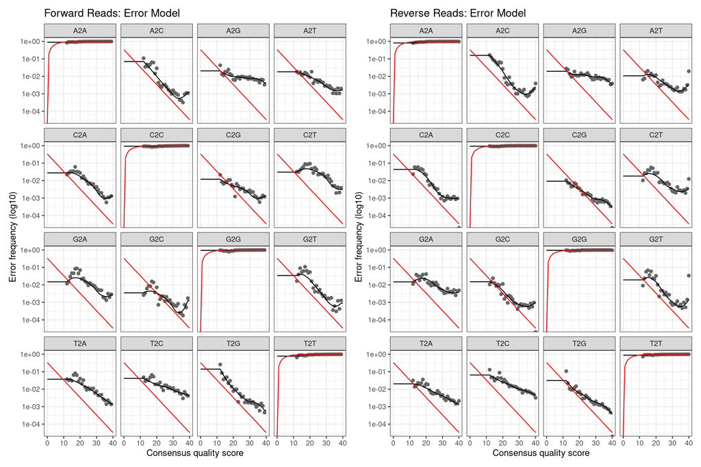

```r
# Reverse Error Plot
reverse_error_plot <-
  plotErrors(error_reverse_reads, nominalQ = TRUE) +
  labs(title = "Reverse Reads: Error Model")

# Look at the plots together
forward_error_plot + reverse_error_plot
```

# Infer ASVs

```r
# Infer ASVs on the forward sequences
dada_forward <-
  dada(filtered_forward_reads,
       err = error_forward_reads,
       multithread = n_threads)
```

```
## Sample 1 - 117162 reads in 48323 unique sequences.
## Sample 2 - 106246 reads in 46199 unique sequences.
## Sample 3 - 273873 reads in 81040 unique sequences.
## Sample 4 - 148732 reads in 37655 unique sequences.
## Sample 5 - 157811 reads in 67219 unique sequences.
## Sample 6 - 91784 reads in 31423 unique sequences.
## Sample 7 - 130505 reads in 44766 unique sequences.
## Sample 8 - 153077 reads in 58828 unique sequences.
## Sample 9 - 304465 reads in 117601 unique sequences.
## Sample 10 - 144542 reads in 60906 unique sequences.
## Sample 11 - 213749 reads in 87584 unique sequences.
## Sample 12 - 50042 reads in 18436 unique sequences.
## Sample 13 - 154262 reads in 63342 unique sequences.
## Sample 14 - 79104 reads in 36248 unique sequences.
## Sample 15 - 76468 reads in 35378 unique sequences.
## Sample 16 - 63575 reads in 20700 unique sequences.
## Sample 17 - 63983 reads in 35489 unique sequences.
## Sample 18 - 68924 reads in 31408 unique sequences.
## Sample 19 - 49942 reads in 21643 unique sequences.
## Sample 20 - 176647 reads in 69725 unique sequences.
## Sample 21 - 154509 reads in 64595 unique sequences.
## Sample 22 - 198130 reads in 83848 unique sequences.
## Sample 23 - 77124 reads in 34264 unique sequences.
## Sample 24 - 190552 reads in 80231 unique sequences.
## Sample 25 - 180370 reads in 69321 unique sequences.
## Sample 26 - 145820 reads in 63459 unique sequences.
## Sample 27 - 109496 reads in 42747 unique sequences.
## Sample 28 - 81473 reads in 39885 unique sequences.
## Sample 29 - 90900 reads in 41946 unique sequences.
## Sample 30 - 54802 reads in 27194 unique sequences.
## Sample 31 - 96802 reads in 47917 unique sequences.
## Sample 32 - 97206 reads in 35454 unique sequences.
## Sample 33 - 146779 reads in 41003 unique sequences.
## Sample 34 - 139686 reads in 51473 unique sequences.
## Sample 35 - 99158 reads in 46791 unique sequences.
## Sample 36 - 73758 reads in 19395 unique sequences.
## Sample 37 - 89659 reads in 35943 unique sequences.
## Sample 38 - 130136 reads in 60708 unique sequences.
## Sample 39 - 128379 reads in 56191 unique sequences.
## Sample 40 - 138879 reads in 57976 unique sequences.
```

[output cut: 153 more lines]

```
## Sample 194 - 683537 reads in 671001 unique sequences.
## Sample 195 - 383480 reads in 379009 unique sequences.
## Sample 196 - 475976 reads in 468160 unique sequences.
## Sample 197 - 557545 reads in 548020 unique sequences.
## Sample 198 - 563428 reads in 553018 unique sequences.
## Sample 199 - 432074 reads in 426722 unique sequences.
## Sample 200 - 626086 reads in 615225 unique sequences.
## Sample 201 - 588648 reads in 577088 unique sequences.
## Sample 202 - 640001 reads in 628494 unique sequences.
## Sample 203 - 453249 reads in 447275 unique sequences.
## Sample 204 - 744654 reads in 726641 unique sequences.
## Sample 205 - 633373 reads in 622463 unique sequences.
## Sample 206 - 562173 reads in 538869 unique sequences.
## Sample 207 - 362315 reads in 353993 unique sequences.
## Sample 208 - 636561 reads in 621201 unique sequences.
```

```r
# Take a look at the data
# What type of data structure is it?
typeof(dada_forward) # It's a list
```

```
## [1] "list"
```

```r
length(dada_forward) # How big is it? One per sample!
```

```
## [1] 208
```

```r
# What doees it look like for each sample?
dada_forward$`ERR3141386_1_filtered.fastq.gz`
```

```
## dada-class: object describing DADA2 denoising results
## 1724 sequence variants were inferred from 48323 input unique sequences.
## Key parameters: OMEGA_A = 1e-40, OMEGA_C = 1e-40, BAND_SIZE = 16
```

```r
# Reverse ASVs
dada_reverse <-
  dada(filtered_reverse_reads,
       err = error_reverse_reads ,
       multithread = n_threads)
```

```
## Sample 1 - 117162 reads in 50578 unique sequences.
## Sample 2 - 106246 reads in 59093 unique sequences.
## Sample 3 - 273873 reads in 81979 unique sequences.
## Sample 4 - 148732 reads in 52748 unique sequences.
## Sample 5 - 157811 reads in 66136 unique sequences.
## Sample 6 - 91784 reads in 39455 unique sequences.
## Sample 7 - 130505 reads in 42893 unique sequences.
## Sample 8 - 153077 reads in 74878 unique sequences.
## Sample 9 - 304465 reads in 119011 unique sequences.
## Sample 10 - 144542 reads in 74535 unique sequences.
## Sample 11 - 213749 reads in 83283 unique sequences.
## Sample 12 - 50042 reads in 22510 unique sequences.
## Sample 13 - 154262 reads in 79297 unique sequences.
## Sample 14 - 79104 reads in 39798 unique sequences.
## Sample 15 - 76468 reads in 45185 unique sequences.
## Sample 16 - 63575 reads in 23443 unique sequences.
## Sample 17 - 63983 reads in 42826 unique sequences.
## Sample 18 - 68924 reads in 34494 unique sequences.
## Sample 19 - 49942 reads in 27739 unique sequences.
## Sample 20 - 176647 reads in 68009 unique sequences.
## Sample 21 - 154509 reads in 81776 unique sequences.
## Sample 22 - 198130 reads in 86155 unique sequences.
## Sample 23 - 77124 reads in 43279 unique sequences.
## Sample 24 - 190552 reads in 105067 unique sequences.
## Sample 25 - 180370 reads in 69691 unique sequences.
## Sample 26 - 145820 reads in 75486 unique sequences.
## Sample 27 - 109496 reads in 44597 unique sequences.
## Sample 28 - 81473 reads in 49705 unique sequences.
## Sample 29 - 90900 reads in 42995 unique sequences.
## Sample 30 - 54802 reads in 33068 unique sequences.
## Sample 31 - 96802 reads in 48819 unique sequences.
## Sample 32 - 97206 reads in 46651 unique sequences.
## Sample 33 - 146779 reads in 41582 unique sequences.
## Sample 34 - 139686 reads in 57906 unique sequences.
## Sample 35 - 99158 reads in 59150 unique sequences.
## Sample 36 - 73758 reads in 19319 unique sequences.
## Sample 37 - 89659 reads in 43655 unique sequences.
## Sample 38 - 130136 reads in 57083 unique sequences.
## Sample 39 - 128379 reads in 70352 unique sequences.
## Sample 40 - 138879 reads in 54668 unique sequences.
```

[output cut: 153 more lines]

```
## Sample 194 - 683537 reads in 672263 unique sequences.
## Sample 195 - 383480 reads in 379813 unique sequences.
## Sample 196 - 475976 reads in 469086 unique sequences.
## Sample 197 - 557545 reads in 548877 unique sequences.
## Sample 198 - 563428 reads in 553499 unique sequences.
## Sample 199 - 432074 reads in 427481 unique sequences.
## Sample 200 - 626086 reads in 615663 unique sequences.
## Sample 201 - 588648 reads in 577799 unique sequences.
## Sample 202 - 640001 reads in 628634 unique sequences.
## Sample 203 - 453249 reads in 448000 unique sequences.
## Sample 204 - 744654 reads in 727309 unique sequences.
## Sample 205 - 633373 reads in 623362 unique sequences.
## Sample 206 - 562173 reads in 540001 unique sequences.
## Sample 207 - 362315 reads in 355226 unique sequences.
## Sample 208 - 636561 reads in 622004 unique sequences.
```

```r
# Check data
dada_reverse[30]
```

```
## $ERR3141415_2_filtered.fastq.gz
## dada-class: object describing DADA2 denoising results
## 839 sequence variants were inferred from 33068 input unique sequences.
## Key parameters: OMEGA_A = 1e-40, OMEGA_C = 1e-40, BAND_SIZE = 16
```

# Merge Forward and Reverse ASVs

```r
merged_ASVs <-
  mergePairs(dada_forward, filtered_forward_reads,
             dada_reverse, filtered_reverse_reads,
             verbose = TRUE)
```

```
## 99063 paired-reads (in 2134 unique pairings) successfully merged out of 109863 (in 5894 pairings) input.
```

```
## 85110 paired-reads (in 2432 unique pairings) successfully merged out of 98128 (in 6244 pairings) input.
```

```
## 249718 paired-reads (in 3843 unique pairings) successfully merged out of 266096 (in 9000 pairings) input.
```

```
## 137732 paired-reads (in 1523 unique pairings) successfully merged out of 144531 (in 3376 pairings) input.
```

```
## 142389 paired-reads (in 1987 unique pairings) successfully merged out of 152582 (in 4590 pairings) input.
```

```
## 81453 paired-reads (in 1321 unique pairings) successfully merged out of 87712 (in 3366 pairings) input.
```

```
## 119689 paired-reads (in 1582 unique pairings) successfully merged out of 126426 (in 3551 pairings) input.
```

```
## 126303 paired-reads (in 2610 unique pairings) successfully merged out of 143174 (in 7422 pairings) input.
```

```
## 263087 paired-reads (in 5164 unique pairings) successfully merged out of 289361 (in 13627 pairings) input.
```

```
## 118753 paired-reads (in 2968 unique pairings) successfully merged out of 134466 (in 7587 pairings) input.
```

```
## 184196 paired-reads (in 3537 unique pairings) successfully merged out of 203097 (in 9904 pairings) input.
```

```
## 45609 paired-reads (in 662 unique pairings) successfully merged out of 48423 (in 1582 pairings) input.
```

```
## 132337 paired-reads (in 2509 unique pairings) successfully merged out of 146485 (in 6733 pairings) input.
```

```
## 65904 paired-reads (in 1368 unique pairings) successfully merged out of 74079 (in 4282 pairings) input.
```

```
## 63361 paired-reads (in 1136 unique pairings) successfully merged out of 71308 (in 3721 pairings) input.
```

```
## 58435 paired-reads (in 606 unique pairings) successfully merged out of 61848 (in 1563 pairings) input.
```

```
## 50225 paired-reads (in 1115 unique pairings) successfully merged out of 58946 (in 4016 pairings) input.
```

```
## 56551 paired-reads (in 1223 unique pairings) successfully merged out of 64123 (in 3631 pairings) input.
```

```
## 44054 paired-reads (in 597 unique pairings) successfully merged out of 47320 (in 1561 pairings) input.
```

```
## 158685 paired-reads (in 2129 unique pairings) successfully merged out of 170197 (in 5845 pairings) input.
```

```
## 125527 paired-reads (in 3139 unique pairings) successfully merged out of 143146 (in 9799 pairings) input.
```

```
## 160063 paired-reads (in 4026 unique pairings) successfully merged out of 183542 (in 12707 pairings) input.
```

```
## 63025 paired-reads (in 1281 unique pairings) successfully merged out of 71514 (in 4052 pairings) input.
```

```
## 160209 paired-reads (in 2638 unique pairings) successfully merged out of 180784 (in 9999 pairings) input.
```

```
## 157383 paired-reads (in 3051 unique pairings) successfully merged out of 171675 (in 7738 pairings) input.
```

```
## 119342 paired-reads (in 2529 unique pairings) successfully merged out of 136248 (in 7743 pairings) input.
```

```
## 94377 paired-reads (in 1778 unique pairings) successfully merged out of 103728 (in 4708 pairings) input.
```

```
## 64988 paired-reads (in 1469 unique pairings) successfully merged out of 75240 (in 4802 pairings) input.
```

```
## 70849 paired-reads (in 2201 unique pairings) successfully merged out of 82744 (in 6239 pairings) input.
```

```
## 42756 paired-reads (in 1021 unique pairings) successfully merged out of 49671 (in 3319 pairings) input.
```

```
## 74623 paired-reads (in 2388 unique pairings) successfully merged out of 87947 (in 6374 pairings) input.
```

```
## 86133 paired-reads (in 1160 unique pairings) successfully merged out of 92952 (in 3256 pairings) input.
```

```
## 137487 paired-reads (in 1932 unique pairings) successfully merged out of 143100 (in 3591 pairings) input.
```

```
## 120353 paired-reads (in 2239 unique pairings) successfully merged out of 132525 (in 6071 pairings) input.
```

```
## 82036 paired-reads (in 1690 unique pairings) successfully merged out of 93277 (in 4963 pairings) input.
```

```
## 69725 paired-reads (in 767 unique pairings) successfully merged out of 72753 (in 1489 pairings) input.
```

```
## 73095 paired-reads (in 1597 unique pairings) successfully merged out of 83050 (in 4344 pairings) input.
```

```
## 108888 paired-reads (in 2354 unique pairings) successfully merged out of 122535 (in 6989 pairings) input.
```

```
## 108261 paired-reads (in 2331 unique pairings) successfully merged out of 120739 (in 6175 pairings) input.
```

```
## 114905 paired-reads (in 2876 unique pairings) successfully merged out of 129614 (in 7662 pairings) input.
```

```
## 99515 paired-reads (in 2084 unique pairings) successfully merged out of 109391 (in 5596 pairings) input.
```

```
## 55859 paired-reads (in 1686 unique pairings) successfully merged out of 63675 (in 4246 pairings) input.
```

```
## 90925 paired-reads (in 2416 unique pairings) successfully merged out of 102372 (in 6350 pairings) input.
```

```
## 123191 paired-reads (in 2806 unique pairings) successfully merged out of 136291 (in 7309 pairings) input.
```

```
## 57559 paired-reads (in 902 unique pairings) successfully merged out of 63533 (in 2663 pairings) input.
```

```
## 88487 paired-reads (in 1623 unique pairings) successfully merged out of 97342 (in 4424 pairings) input.
```

```
## 52115 paired-reads (in 1544 unique pairings) successfully merged out of 63004 (in 5285 pairings) input.
```

```
## 39765 paired-reads (in 982 unique pairings) successfully merged out of 48975 (in 3946 pairings) input.
```

```
## 25562 paired-reads (in 803 unique pairings) successfully merged out of 30348 (in 2109 pairings) input.
```

```
## 46745 paired-reads (in 1030 unique pairings) successfully merged out of 54948 (in 3715 pairings) input.
```

```
## 66187 paired-reads (in 1495 unique pairings) successfully merged out of 74016 (in 4677 pairings) input.
```

```
## 59555 paired-reads (in 840 unique pairings) successfully merged out of 65610 (in 3159 pairings) input.
```

```
## 254769 paired-reads (in 6427 unique pairings) successfully merged out of 286161 (in 18192 pairings) input.
```

```
## 104159 paired-reads (in 1780 unique pairings) successfully merged out of 111651 (in 4037 pairings) input.
```

```
## 96482 paired-reads (in 1510 unique pairings) successfully merged out of 104090 (in 3668 pairings) input.
```

```
## 174548 paired-reads (in 4471 unique pairings) successfully merged out of 196401 (in 12342 pairings) input.
```

```
## 77265 paired-reads (in 2046 unique pairings) successfully merged out of 87638 (in 4739 pairings) input.
```

```
## 99996 paired-reads (in 2296 unique pairings) successfully merged out of 112163 (in 6020 pairings) input.
```

```
## 137787 paired-reads (in 3316 unique pairings) successfully merged out of 156440 (in 9458 pairings) input.
```

```
## 135655 paired-reads (in 2713 unique pairings) successfully merged out of 150062 (in 7506 pairings) input.
```

```
## 249931 paired-reads (in 4857 unique pairings) successfully merged out of 273372 (in 13314 pairings) input.
```

```
## 90107 paired-reads (in 2512 unique pairings) successfully merged out of 104148 (in 6143 pairings) input.
```

```
## 135043 paired-reads (in 3771 unique pairings) successfully merged out of 151543 (in 9085 pairings) input.
```

```
## 138008 paired-reads (in 3105 unique pairings) successfully merged out of 154529 (in 7972 pairings) input.
```

```
## 111297 paired-reads (in 2675 unique pairings) successfully merged out of 131008 (in 10514 pairings) input.
```

```
## 158886 paired-reads (in 3601 unique pairings) successfully merged out of 177837 (in 10493 pairings) input.
```

```
## 125633 paired-reads (in 1357 unique pairings) successfully merged out of 130165 (in 3468 pairings) input.
```

```
## 142120 paired-reads (in 2569 unique pairings) successfully merged out of 152687 (in 5687 pairings) input.
```

```
## 8346 paired-reads (in 274 unique pairings) successfully merged out of 10671 (in 869 pairings) input.
```

```
## 199079 paired-reads (in 3492 unique pairings) successfully merged out of 216068 (in 8522 pairings) input.
```

```
## 168190 paired-reads (in 2933 unique pairings) successfully merged out of 184128 (in 7363 pairings) input.
```

```
## 152494 paired-reads (in 3047 unique pairings) successfully merged out of 165385 (in 6932 pairings) input.
```

```
## 133199 paired-reads (in 2485 unique pairings) successfully merged out of 146664 (in 6011 pairings) input.
```

```
## 75377 paired-reads (in 1465 unique pairings) successfully merged out of 82293 (in 3072 pairings) input.
```

```
## 100391 paired-reads (in 1774 unique pairings) successfully merged out of 109779 (in 4277 pairings) input.
```

```
## 108638 paired-reads (in 1588 unique pairings) successfully merged out of 115642 (in 3412 pairings) input.
```

```
## 73702 paired-reads (in 1599 unique pairings) successfully merged out of 83192 (in 4074 pairings) input.
```

```
## 121381 paired-reads (in 2113 unique pairings) successfully merged out of 133711 (in 5513 pairings) input.
```

```
## 101921 paired-reads (in 645 unique pairings) successfully merged out of 103820 (in 1094 pairings) input.
```

```
## 95309 paired-reads (in 562 unique pairings) successfully merged out of 97136 (in 981 pairings) input.
```

```
## 54125 paired-reads (in 381 unique pairings) successfully merged out of 55293 (in 693 pairings) input.
```

```
## 110506 paired-reads (in 653 unique pairings) successfully merged out of 112614 (in 1181 pairings) input.
```

```
## 62513 paired-reads (in 450 unique pairings) successfully merged out of 63846 (in 790 pairings) input.
```

```
## 78454 paired-reads (in 504 unique pairings) successfully merged out of 79740 (in 821 pairings) input.
```

```
## 69204 paired-reads (in 592 unique pairings) successfully merged out of 71643 (in 1308 pairings) input.
```

```
## 97906 paired-reads (in 637 unique pairings) successfully merged out of 100089 (in 1230 pairings) input.
```

```
## 116011 paired-reads (in 769 unique pairings) successfully merged out of 118662 (in 1446 pairings) input.
```

```
## 87959 paired-reads (in 747 unique pairings) successfully merged out of 89931 (in 1273 pairings) input.
```

```
## 80651 paired-reads (in 710 unique pairings) successfully merged out of 82564 (in 1278 pairings) input.
```

```
## 95812 paired-reads (in 674 unique pairings) successfully merged out of 97735 (in 1176 pairings) input.
```

```
## 84777 paired-reads (in 827 unique pairings) successfully merged out of 86946 (in 1494 pairings) input.
```

```
## 109489 paired-reads (in 926 unique pairings) successfully merged out of 112050 (in 1622 pairings) input.
```

```
## 126867 paired-reads (in 1182 unique pairings) successfully merged out of 129770 (in 2030 pairings) input.
```

```
## 94824 paired-reads (in 847 unique pairings) successfully merged out of 97664 (in 1706 pairings) input.
```

```
## 92470 paired-reads (in 1108 unique pairings) successfully merged out of 95974 (in 2203 pairings) input.
```

```
## 94010 paired-reads (in 732 unique pairings) successfully merged out of 96862 (in 1468 pairings) input.
```

```
## 101961 paired-reads (in 1955 unique pairings) successfully merged out of 112955 (in 5262 pairings) input.
```

```
## 54004 paired-reads (in 1328 unique pairings) successfully merged out of 59879 (in 2924 pairings) input.
```

```
## 176117 paired-reads (in 2316 unique pairings) successfully merged out of 185021 (in 4686 pairings) input.
```

```
## 98536 paired-reads (in 1397 unique pairings) successfully merged out of 103311 (in 2489 pairings) input.
```

```
## 89070 paired-reads (in 1677 unique pairings) successfully merged out of 98092 (in 4577 pairings) input.
```

```
## 124279 paired-reads (in 3959 unique pairings) successfully merged out of 144879 (in 10328 pairings) input.
```

```
## 45820 paired-reads (in 1838 unique pairings) successfully merged out of 56297 (in 4827 pairings) input.
```

```
## 28070 paired-reads (in 743 unique pairings) successfully merged out of 32682 (in 2180 pairings) input.
```

```
## 76813 paired-reads (in 2213 unique pairings) successfully merged out of 87970 (in 4984 pairings) input.
```

```
## 83703 paired-reads (in 2477 unique pairings) successfully merged out of 97743 (in 6583 pairings) input.
```

```
## 137560 paired-reads (in 2500 unique pairings) successfully merged out of 152426 (in 6965 pairings) input.
```

```
## 97041 paired-reads (in 1467 unique pairings) successfully merged out of 102067 (in 3116 pairings) input.
```

```
## 67437 paired-reads (in 2313 unique pairings) successfully merged out of 79967 (in 6188 pairings) input.
```

```
## 96312 paired-reads (in 2137 unique pairings) successfully merged out of 106598 (in 4833 pairings) input.
```

```
## 38985 paired-reads (in 950 unique pairings) successfully merged out of 44784 (in 2534 pairings) input.
```

```
## 104868 paired-reads (in 1788 unique pairings) successfully merged out of 111866 (in 3967 pairings) input.
```

```
## 116533 paired-reads (in 3187 unique pairings) successfully merged out of 134901 (in 8750 pairings) input.
```

```
## 128968 paired-reads (in 1303 unique pairings) successfully merged out of 134412 (in 3343 pairings) input.
```

```
## 80059 paired-reads (in 1954 unique pairings) successfully merged out of 90026 (in 4632 pairings) input.
```

```
## 10509 paired-reads (in 116 unique pairings) successfully merged out of 10882 (in 217 pairings) input.
```

```
## 72248 paired-reads (in 1927 unique pairings) successfully merged out of 82478 (in 4400 pairings) input.
```

```
## 44077 paired-reads (in 1074 unique pairings) successfully merged out of 51637 (in 2741 pairings) input.
```

```
## 59880 paired-reads (in 559 unique pairings) successfully merged out of 62972 (in 1318 pairings) input.
```

```
## 101775 paired-reads (in 887 unique pairings) successfully merged out of 107622 (in 2082 pairings) input.
```

```
## 86624 paired-reads (in 1584 unique pairings) successfully merged out of 94058 (in 3636 pairings) input.
```

```
## 117069 paired-reads (in 2057 unique pairings) successfully merged out of 128689 (in 5407 pairings) input.
```

```
## 118654 paired-reads (in 3711 unique pairings) successfully merged out of 139281 (in 10258 pairings) input.
```

```
## 116702 paired-reads (in 2436 unique pairings) successfully merged out of 130588 (in 7058 pairings) input.
```

```
## 160113 paired-reads (in 4101 unique pairings) successfully merged out of 182016 (in 10883 pairings) input.
```

```
## 89233 paired-reads (in 2326 unique pairings) successfully merged out of 102646 (in 6510 pairings) input.
```

```
## 46485 paired-reads (in 923 unique pairings) successfully merged out of 52073 (in 2953 pairings) input.
```

```
## 99434 paired-reads (in 2623 unique pairings) successfully merged out of 113176 (in 7049 pairings) input.
```

```
## 106706 paired-reads (in 3899 unique pairings) successfully merged out of 127088 (in 10820 pairings) input.
```

```
## 100276 paired-reads (in 2240 unique pairings) successfully merged out of 112870 (in 5937 pairings) input.
```

```
## 104167 paired-reads (in 3606 unique pairings) successfully merged out of 125375 (in 10949 pairings) input.
```

```
## 110562 paired-reads (in 2221 unique pairings) successfully merged out of 121258 (in 5427 pairings) input.
```

```
## 119730 paired-reads (in 2922 unique pairings) successfully merged out of 135617 (in 9446 pairings) input.
```

```
## 69330 paired-reads (in 1936 unique pairings) successfully merged out of 78022 (in 4737 pairings) input.
```

```
## 41073 paired-reads (in 1345 unique pairings) successfully merged out of 50449 (in 4700 pairings) input.
```

```
## 145929 paired-reads (in 2567 unique pairings) successfully merged out of 159371 (in 8719 pairings) input.
```

```
## 75995 paired-reads (in 2673 unique pairings) successfully merged out of 90405 (in 7520 pairings) input.
```

```
## 105908 paired-reads (in 2152 unique pairings) successfully merged out of 116732 (in 5973 pairings) input.
```

```
## 107842 paired-reads (in 2975 unique pairings) successfully merged out of 126615 (in 9291 pairings) input.
```

```
## 158426 paired-reads (in 3898 unique pairings) successfully merged out of 177182 (in 9580 pairings) input.
```

```
## 132536 paired-reads (in 2619 unique pairings) successfully merged out of 147971 (in 9695 pairings) input.
```

```
## 47741 paired-reads (in 886 unique pairings) successfully merged out of 51091 (in 2249 pairings) input.
```

```
## 116197 paired-reads (in 3751 unique pairings) successfully merged out of 138361 (in 11422 pairings) input.
```

```
## 128246 paired-reads (in 2392 unique pairings) successfully merged out of 141443 (in 6895 pairings) input.
```

```
## 78435 paired-reads (in 2214 unique pairings) successfully merged out of 94587 (in 7905 pairings) input.
```

```
## 111663 paired-reads (in 1890 unique pairings) successfully merged out of 123445 (in 5877 pairings) input.
```

```
## 82165 paired-reads (in 1686 unique pairings) successfully merged out of 90845 (in 4527 pairings) input.
```

```
## 145104 paired-reads (in 2352 unique pairings) successfully merged out of 157524 (in 7316 pairings) input.
```

```
## 104741 paired-reads (in 2924 unique pairings) successfully merged out of 121243 (in 8137 pairings) input.
```

```
## 41095 paired-reads (in 1427 unique pairings) successfully merged out of 52972 (in 5753 pairings) input.
```

```
## 78546 paired-reads (in 2188 unique pairings) successfully merged out of 91190 (in 6147 pairings) input.
```

```
## 57604 paired-reads (in 1495 unique pairings) successfully merged out of 65191 (in 3589 pairings) input.
```

```
## 51601 paired-reads (in 1623 unique pairings) successfully merged out of 59849 (in 3614 pairings) input.
```

```
## 41110 paired-reads (in 1036 unique pairings) successfully merged out of 44749 (in 1753 pairings) input.
```

```
## 45242 paired-reads (in 1200 unique pairings) successfully merged out of 49920 (in 2641 pairings) input.
```

```
## 91902 paired-reads (in 2694 unique pairings) successfully merged out of 108874 (in 8031 pairings) input.
```

```
## 52938 paired-reads (in 1483 unique pairings) successfully merged out of 66598 (in 6463 pairings) input.
```

```
## 37150 paired-reads (in 1333 unique pairings) successfully merged out of 47920 (in 5040 pairings) input.
```

```
## 95994 paired-reads (in 2311 unique pairings) successfully merged out of 106561 (in 5968 pairings) input.
```

```
## 72626 paired-reads (in 2409 unique pairings) successfully merged out of 85003 (in 6449 pairings) input.
```

```
## 36399 paired-reads (in 1382 unique pairings) successfully merged out of 46626 (in 5429 pairings) input.
```

```
## 79575 paired-reads (in 3432 unique pairings) successfully merged out of 95962 (in 8515 pairings) input.
```

```
## 79100 paired-reads (in 3366 unique pairings) successfully merged out of 95601 (in 8493 pairings) input.
```

```
## 92219 paired-reads (in 3316 unique pairings) successfully merged out of 110734 (in 9094 pairings) input.
```

```
## 102086 paired-reads (in 1074 unique pairings) successfully merged out of 107784 (in 2752 pairings) input.
```

```
## 60445 paired-reads (in 1654 unique pairings) successfully merged out of 69728 (in 3889 pairings) input.
```

```
## 80315 paired-reads (in 1444 unique pairings) successfully merged out of 85543 (in 2921 pairings) input.
```

```
## 88704 paired-reads (in 1314 unique pairings) successfully merged out of 96735 (in 3686 pairings) input.
```

```
## 44790 paired-reads (in 569 unique pairings) successfully merged out of 46896 (in 1292 pairings) input.
```

```
## 186779 paired-reads (in 2559 unique pairings) successfully merged out of 196654 (in 5632 pairings) input.
```

```
## 42637 paired-reads (in 865 unique pairings) successfully merged out of 49407 (in 2943 pairings) input.
```

```
## 115424 paired-reads (in 672 unique pairings) successfully merged out of 117897 (in 1235 pairings) input.
```

```
## 102316 paired-reads (in 1707 unique pairings) successfully merged out of 110231 (in 4074 pairings) input.
```

```
## 132127 paired-reads (in 2948 unique pairings) successfully merged out of 149480 (in 8227 pairings) input.
```

```
## 36340 paired-reads (in 833 unique pairings) successfully merged out of 41925 (in 2852 pairings) input.
```

```
## 150902 paired-reads (in 1789 unique pairings) successfully merged out of 156985 (in 3437 pairings) input.
```

```
## 90562 paired-reads (in 2213 unique pairings) successfully merged out of 103504 (in 6714 pairings) input.
```

```
## 100401 paired-reads (in 2349 unique pairings) successfully merged out of 111584 (in 6095 pairings) input.
```

```
## 136268 paired-reads (in 2335 unique pairings) successfully merged out of 146773 (in 5525 pairings) input.
```

```
## 88567 paired-reads (in 1469 unique pairings) successfully merged out of 95714 (in 3615 pairings) input.
```

```
## 107517 paired-reads (in 1855 unique pairings) successfully merged out of 114538 (in 4150 pairings) input.
```

```
## 67303 paired-reads (in 1117 unique pairings) successfully merged out of 72509 (in 2633 pairings) input.
```

```
## 89659 paired-reads (in 1642 unique pairings) successfully merged out of 96316 (in 3928 pairings) input.
```

```
## 135875 paired-reads (in 2802 unique pairings) successfully merged out of 147031 (in 6686 pairings) input.
```

```
## 156761 paired-reads (in 2849 unique pairings) successfully merged out of 167962 (in 6423 pairings) input.
```

```
## 106660 paired-reads (in 1742 unique pairings) successfully merged out of 113210 (in 3790 pairings) input.
```

```
## 142453 paired-reads (in 2287 unique pairings) successfully merged out of 150635 (in 4833 pairings) input.
```

```
## 52714 paired-reads (in 904 unique pairings) successfully merged out of 57346 (in 2481 pairings) input.
```

```
## 93172 paired-reads (in 1246 unique pairings) successfully merged out of 97788 (in 2710 pairings) input.
```

```
## 63276 paired-reads (in 891 unique pairings) successfully merged out of 66677 (in 2023 pairings) input.
```

```
## 95426 paired-reads (in 920 unique pairings) successfully merged out of 99598 (in 2021 pairings) input.
```

```
## 122121 paired-reads (in 1257 unique pairings) successfully merged out of 127644 (in 2626 pairings) input.
```

```
## 27527 paired-reads (in 4531 unique pairings) successfully merged out of 43492 (in 8366 pairings) input.
```

```
## 39444 paired-reads (in 6181 unique pairings) successfully merged out of 66468 (in 12365 pairings) input.
```

```
## Duplicate sequences in merged output.
```

```
## 15853 paired-reads (in 2778 unique pairings) successfully merged out of 24008 (in 4625 pairings) input.
```

```
## 25338 paired-reads (in 4236 unique pairings) successfully merged out of 41624 (in 8572 pairings) input.
```

```
## 31406 paired-reads (in 5466 unique pairings) successfully merged out of 50744 (in 10591 pairings) input.
```

```
## 34771 paired-reads (in 6504 unique pairings) successfully merged out of 57058 (in 12550 pairings) input.
```

```
## 20105 paired-reads (in 3481 unique pairings) successfully merged out of 29843 (in 6020 pairings) input.
```

```
## 39915 paired-reads (in 5573 unique pairings) successfully merged out of 64114 (in 11414 pairings) input.
```

```
## Duplicate sequences in merged output.
```

```
## 41157 paired-reads (in 5741 unique pairings) successfully merged out of 64151 (in 11197 pairings) input.
```

```
## Duplicate sequences in merged output.
```

```
## 41019 paired-reads (in 5518 unique pairings) successfully merged out of 65993 (in 11459 pairings) input.
```

```
## 21286 paired-reads (in 3597 unique pairings) successfully merged out of 33857 (in 6634 pairings) input.
```

```
## 60987 paired-reads (in 7218 unique pairings) successfully merged out of 99870 (in 15650 pairings) input.
```

```
## Duplicate sequences in merged output.
```

```
## 39672 paired-reads (in 5332 unique pairings) successfully merged out of 62721 (in 10647 pairings) input.
```

```
## Duplicate sequences in merged output.
```

```
## 82319 paired-reads (in 6826 unique pairings) successfully merged out of 125540 (in 15301 pairings) input.
```

```
## Duplicate sequences in merged output.
```

```
## 32137 paired-reads (in 3835 unique pairings) successfully merged out of 48541 (in 7241 pairings) input.
```

```
## Duplicate sequences in merged output.
```

```
## 53733 paired-reads (in 6014 unique pairings) successfully merged out of 86301 (in 13206 pairings) input.
```

```r
# Evaluate the data output
typeof(merged_ASVs) # A list
```

```
## [1] "list"
```

```r
length(merged_ASVs) # Length of the number of samples!
```

```
## [1] 208
```

```r
head(names(merged_ASVs)) # Here, we can access our current sample names
```

```
## [1] "ERR3141386_1_filtered.fastq.gz" "ERR3141387_1_filtered.fastq.gz"
## [3] "ERR3141388_1_filtered.fastq.gz" "ERR3141389_1_filtered.fastq.gz"
## [5] "ERR3141390_1_filtered.fastq.gz" "ERR3141391_1_filtered.fastq.gz"
```

```r
# Inspect further for each sample
#head(merged_ASVs, n = 2) # A dataframe for each sample
# We have a dataframe in each part of our list! What are in the columns?
glimpse(merged_ASVs$`ERR3141386_1_filtered.fastq.gz`)
```

```
## Rows: 2,134
## Columns: 9
## $ sequence  <chr> "TGAGGAATATTGGACAATGGGTGAGAGCCTGATCCAGCCATCCCGCGTGAAGGATGACG…
## $ abundance <int> 9775, 7762, 4608, 4462, 4025, 2796, 1705, 1210, 1162, 1073, …
## $ forward   <int> 1, 2, 4, 3, 5, 6, 7, 9, 10, 8, 13, 17, 14, 3, 11, 19, 18, 20…
## $ reverse   <int> 1, 2, 3, 1, 4, 5, 7, 9, 6, 11, 12, 18, 8, 15, 17, 19, 16, 20…
## $ nmatch    <int> 29, 23, 44, 29, 24, 204, 24, 24, 23, 24, 44, 204, 24, 29, 24…
## $ nmismatch <int> 0, 0, 0, 0, 0, 0, 0, 0, 0, 0, 0, 0, 0, 0, 0, 0, 0, 0, 0, 0, …
## $ nindel    <int> 0, 0, 0, 0, 0, 0, 0, 0, 0, 0, 0, 0, 0, 0, 0, 0, 0, 0, 0, 0, …
## $ prefer    <dbl> 2, 1, 1, 2, 1, 2, 1, 1, 2, 1, 1, 1, 2, 1, 1, 2, 2, 1, 1, 1, …
## $ accept    <lgl> TRUE, TRUE, TRUE, TRUE, TRUE, TRUE, TRUE, TRUE, TRUE, TRUE, …
```

# Create Raw ASV Count Table

```r
# Raw ASV
raw_ASV_table <- makeSequenceTable(merged_ASVs)
```

```
## Duplicate sequences detected and merged.
## Duplicate sequences detected and merged.
## Duplicate sequences detected and merged.
## Duplicate sequences detected and merged.
## Duplicate sequences detected and merged.
## Duplicate sequences detected and merged.
## Duplicate sequences detected and merged.
```

```r
# Intuition Check: Type and dimensions of the data
dim(raw_ASV_table)
```

```
## [1]    208 250208
```

```r
typeof(raw_ASV_table)
```

```
## [1] "integer"
```

```r
class(raw_ASV_table)
```

```
## [1] "matrix" "array"
```

```r
# write out raw_asv_table
write.table(raw_ASV_table, file = "data/01_DADA2/raw_ASV_counts.tsv",
            sep = "\t", quote = FALSE, col.names = NA)
```

# Assess ASV Quality

## INTERPRETATION #1: What are the current ASV lengths?

1. *What is the sequencing strategy?*
   - Illumina MiSeq paired-end 250bp (2x250bp) was used.
   - 341F and 805R primers were used to amplify the V3-V4 hypervariable regions of the 16S rRNA gene.
2. *What’s the total length of our starting amplicons?*
   - Our primers are named after the location they bind to on the 16S gene. So:
   - `805 - 341 = 464`
   - The total length of the starting amplicon is 464 base pairs, with primers.
3. *What is the ASV length without primers?*
   - The 341F (5′-CCTACGGGNGGCWGCAG) primer is 17 base pairs.
   - The 805R (5′-GACTACHVGGGTATCTAATCC) primer is 21 base pairs.
   - `464 - 17 - 21 = 426`
   - The expected ASV length without primers is **426 base pairs**.
4. *What is the length of the trimmed ASVs after `filterAndTrim()`?*
   - In my `01_QualityTrimming.Rmd`, I used `trimLeft = c(17,21)` to remove the 17bp primer at the beginning of the forward reads and the 21bp primer at the beginning of the reverse reads. I also used `truncLen = c(249, 240)`, which removed 1 base at the end of the forward reads and removed 10 bases at the end of the reverse read. Therefore, the length of the trimmed ASV should be 426 base pairs, as the bases removed at the end of the read are just removed from the overlapping region of the ASV.
5. *What is the overlap between our forward and reverse reads?*
   - We performed 2x250 paired-end Illumina MiSeq Sequencing. Originally the overlapping region between forard and reverse reads was calculated to be 36bp (250+250-464=36). By trimming low quality bases from the end of our reads (one base from forward read and ten bases from reverse read) the overlapping region is calculated to be 25bp.

### ASV Length Stats

```r
# Calculate summary stats
# Longest ASV?
maxLength_ASV <- max(nchar(getSequences(raw_ASV_table)))
maxLength_ASV
```

```
## [1] 439
```

```r
# Shortest ASV?
minLength_ASV <- min(nchar(getSequences(raw_ASV_table)))
minLength_ASV
```

```
## [1] 232
```

```r
# Mean ASV length?
meanLength_ASV <- mean(nchar(getSequences(raw_ASV_table)))
meanLength_ASV
```

```
## [1] 391.8168
```

```r
# Median ASV length?
medianLength_ASV <- median(nchar(getSequences(raw_ASV_table)))
medianLength_ASV
```

```
## [1] 408
```

```r
# Create a table to Inspect the distribution of sequence lengths of all ASVs in dataset
table(nchar(getSequences(raw_ASV_table)))
```

```
##
##   232   233   234   235   236   237   238   239   240   241   242   243   244
##  2687   421   462   405   422   384   398   408   456   428   462   483   502
##   245   246   247   248   249   250   251   252   253   254   255   256   257
##   404   398   530   422   457   417   490   529   506   417   455   393   420
##   258   259   260   261   262   263   264   265   266   267   268   269   270
##   404   585  1531   425   450   381   450   460   393   418   419   409   396
##   271   272   273   274   275   276   277   278   279   280   281   282   283
##   430   357   408   411   676   581   457   462   375   363   352   353   303
##   284   285   286   287   288   289   290   291   292   293   294   295   296
##   356   320   297   324   359   327   366   362   345   294   296   240   315
##   297   298   299   300   301   302   303   304   305   306   307   308   309
##   304   656   385   284   268   209   241   195   231   222   205   208   209
##   310   311   312   313   314   315   316   317   318   319   320   321   322
##   232   261   218   269   208   240   235   233   208   204   214   271   203
```

[output cut: 18 more lines]

### ASV Length Plot

Here’s some of the stats that we’ve calculated:

- Max ASV length: 439 base pairs
- Min ASV length: 232 base pairs
- Mean ASV length: 391.8168324 base pairs
- Median ASV length: 408 base pairs

Now, we will plot these ASV lengths to give us a better idea:

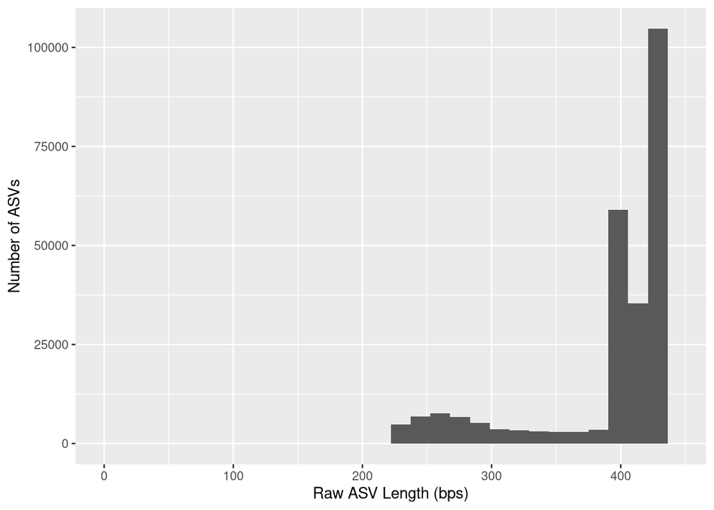

```r
# Inspect the distribution of sequence lengths of all ASVs in data set
# AFTER TRIM
plot_ASVLength_raw <-
  data.frame(Seq_Length = nchar(getSequences(raw_ASV_table))) %>%
  ggplot(aes(x = Seq_Length )) +
  geom_histogram() +
  # include the x-axis scales
  scale_x_continuous(limits = c(0, maxLength_ASV + 5)) +
  labs(y = "Number of ASVs", x = "Raw ASV Length (bps)")

# Show the plot
plot_ASVLength_raw
```

INTERPRETATION #2:

The ASV length data does not quite match my hypotheses from Interpretation #1. I expected most of the ASVs to have a length of 426bp. From the table we see that we have quite the variation in ASV length. From the plot we can visualize the variation, with most ASVs having a length between 390bp - 440bp.

My shortest ASV length is 232bp, my mean ASV length is 391bp, and my median ASV length is 408bp. There is an 18bp difference between my expected median ASV length (426bp) and my actual median ASV length (408bp).

INTERPRETATION #3: Taking into account INTERPRETATIONS #1 and #2, what is your suggested trimming procedure for your ASV lengths? Will you allow some variation or trim to an exact length, similar to our in class example here?

Since I have quite a bit of variation in ASV length, yes I think I think I will allow some variation instead of trimming to an exact length. Based on the ASV length data I’ve generated above, I think I will trim ASV length to a range of 408bp - 429bp.Note that I was originally going to have this range be between 408 - 426bp (my median length to expected length), but extended the range to 429bp to include the large number of ASVs that were between 427 and 429bp in length. My original range of 408bp - 426bp only retained 18% of my ASVs.

## Trim ASV lengths

Now that we are pretty convinced that we have some spurious ASVs, we will trim ASVs that are higher or lower than 408bp - 429bp base pairs in this data set.

```r
# Subset only ASVs that are between 408 and 426 bps long
raw_ASV_table_trimmed <-
  raw_ASV_table[,nchar(colnames(raw_ASV_table)) %in% 408:429]


# Inspect the distribution of sequence lengths of all ASVs in dataset
table(nchar(getSequences(raw_ASV_table_trimmed)))
```

```
##
##   408   409   410   411   412   413   414   415   416   417   418   419   420
##  2740  1734  1251  1095   491   407   402   580   700   509   785  1708  1130
##   421   422   423   424   425   426   427   428   429
##  6342 15159  1396  1058   771  8397 56885 18438  1026
```

```r
# What proportion of total ASV sequences are left in the data?
percRetained_Trimmed <- sum(raw_ASV_table_trimmed)/sum(raw_ASV_table)
percRetained_Trimmed # Show it
```

```
## [1] 0.6683215
```

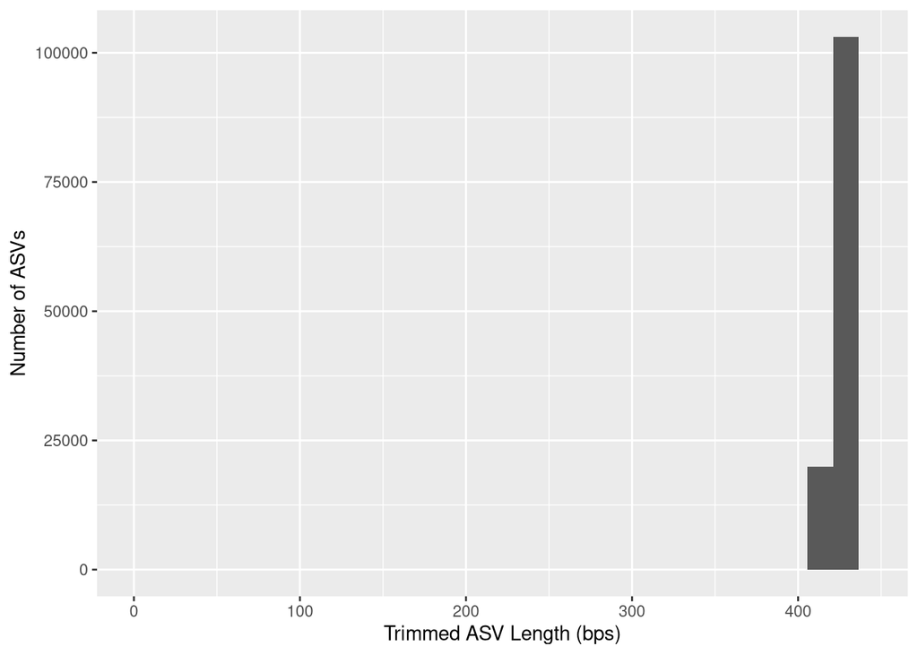

```r
# Inspect the distribution of sequence lengths of all ASVs in dataset
# AFTER TRIM
plot_ASVLength_trimmed <-
  data.frame(Seq_Length = nchar(getSequences(raw_ASV_table_trimmed))) %>%
  ggplot(aes(x = Seq_Length )) +
  geom_histogram() +
  # include the x-axis scales
  scale_x_continuous(limits = c(0, maxLength_ASV + 5)) +
  labs(y = "Number of ASVs", x = "Trimmed ASV Length (bps)")

# Show the plot
plot_ASVLength_trimmed
```

# Remove Chimeras

```r
# Remove the chimeras in the raw ASV table
noChimeras_ASV_table <-
  removeBimeraDenovo(raw_ASV_table_trimmed,
                     method="consensus",
                     multithread = n_threads,
                     verbose=TRUE)
```

```
## Identified 47670 bimeras out of 123004 input sequences.
```

```r
# Check the dimensions
dim(noChimeras_ASV_table)
```

```
## [1]   208 75334
```

```r
# What proportion is left of the sequences?
# Chimera removal compared to trimming
percRetained_chimerasTrimmed <- sum(noChimeras_ASV_table)/sum(raw_ASV_table_trimmed)
percRetained_chimerasTrimmed
```

```
## [1] 0.920586
```

```r
# Chimera removal compared to raw
percRetained_chimerasRaw <-sum(noChimeras_ASV_table)/sum(raw_ASV_table)
percRetained_chimerasRaw
```

```
## [1] 0.6152475
```

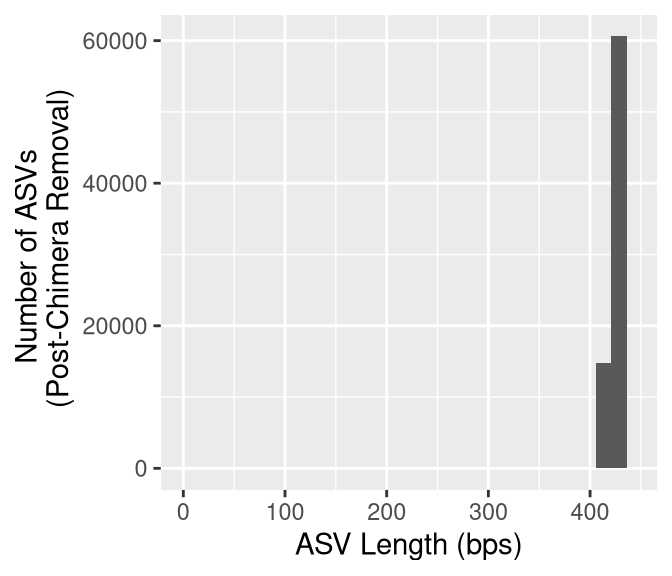

```r
# Plot it
plot_ASVLength_NoChimeras <-
  data.frame(Seq_Length_NoChim = nchar(getSequences(noChimeras_ASV_table))) %>%
  ggplot(aes(x = Seq_Length_NoChim )) +
  geom_histogram()+
  # include the x-axis scales
  scale_x_continuous(limits = c(0, maxLength_ASV + 5)) +
  labs(y = "Number of ASVs \n (Post-Chimera Removal)",
       x = "ASV Length (bps)")

# Show the plot
plot_ASVLength_NoChimeras
```

So, we have removed 47670 ASVs, which were chimeras. Let’s review what proportion of ASVs we have retained along the workflow:

1. 66.83% of the raw ASVs were retained *after trimming*.
2. 92.06% of the trimmed ASV counts were retained *after chimera removal*.
3. This translates to 61.52% retention of the original, raw merged ASV counts after *both trimming and chimera removal.*

INTERPRETATION #4:

1. What proportion of raw ASVs were retained after trimming?
- 66.83% of raw ASVs were retained after trimming?
2. What proportion of the trimmed ASVs were retained after chimera removal?
- 92.06% of the trimmed ASVs were retained after chimera removal
3. What proportion of the total merged ASVs were retained after both trimming and chimera removal? Do you think that the ASV lengths have been trimmed appropriately? For inspiration, you are encouraged to describe the conclusions from the the ASV length plot below.
- 61.52% of the total merged ASVs were retained after both trimming and chimera removal

At this point in time, I am not confident that the ASV lengths have been trimmed appropriately. Initially in the ASV length trimming step, I established a length range of 408bp - 426bp and only 18.22% of the ASVs were retained! I feel much more confident in the range I used for acceptable ASV length, as I now retain 61.52% of the total merged ASVs were after BOTH trimming and chimera removal.

With my initial ASL length trimming paramters keeping ASVs that were between 408 and 426bp, the max number of ASVs at a certain length wer just above 20 000. In the plot below you can see that now this number sits above 100 000. Even with chimera removal, the max number of ASVs after trimming is above 60 000. After a lot of troubleshooting, I am happy with these paramters and confident with the results I am getting.

Big thank you to Sophia for helping me figure this out!

### Plot ASV Lengths

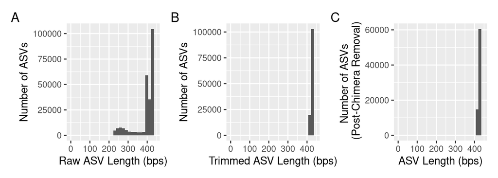

```r
plot_ASVLength_raw + plot_ASVLength_trimmed + plot_ASVLength_NoChimeras +
    plot_annotation(tag_levels = 'A')
```

# Track the read counts

Here, we will look at the number of reads that were lost in the filtering, denoising, merging, and chimera removal.

```r
# A little function to identify number seqs
getN <- function(x) sum(getUniques(x))

# Make the table to track the seqs
track <- cbind(sapply(dada_forward, getN),
               sapply(dada_reverse, getN),
               sapply(merged_ASVs, getN),
               rowSums(noChimeras_ASV_table))
```

```
## Duplicate sequences detected and merged.
## Duplicate sequences detected and merged.
## Duplicate sequences detected and merged.
## Duplicate sequences detected and merged.
## Duplicate sequences detected and merged.
## Duplicate sequences detected and merged.
## Duplicate sequences detected and merged.
```

```r
head(track)
```

```
##                                  [,1]   [,2]   [,3]   [,4]
## ERR3141386_1_filtered.fastq.gz 112784 113612  99063  60993
## ERR3141387_1_filtered.fastq.gz 101592 102152  85110  47011
## ERR3141388_1_filtered.fastq.gz 269420 269937 249718 170431
## ERR3141389_1_filtered.fastq.gz 146380 146413 137732 109452
## ERR3141390_1_filtered.fastq.gz 154699 155175 142389  52547
## ERR3141391_1_filtered.fastq.gz  89399  89588  81453  63605
```

```r
# Update column names to be more informative (most are missing at the moment!)
colnames(track) <- c("denoisedF", "denoisedR", "merged", "nochim")
rownames(track) <- row.names(noChimeras_ASV_table)

# Generate a dataframe to track the reads through our DADA2 pipeline
track_counts_df <-
  track %>%
  # make it a dataframe
  as.data.frame() %>%
  rownames_to_column(var = "sample_names")

# Now let's add a column for the number of ASVs
# First, intuition check that the samples match
stopifnot(track_counts_df$sample_names == row.names(noChimeras_ASV_table))

# Now, let's add a new column with the number of ASVs
track_counts_df <-
  track_counts_df %>%
  mutate(num_ASVs = rowSums(noChimeras_ASV_table > 1))

# Visualize it in table format
DT::datatable(track_counts_df)
```

|  | sample_names | denoisedF | denoisedR | merged | nochim | num_ASVs |
| --- | --- | --- | --- | --- | --- | --- |
| 1 | ERR3141386_1_filtered.fastq.gz | 112784 | 113612 | 99063 | 60993 | 794 |
| 2 | ERR3141387_1_filtered.fastq.gz | 101592 | 102152 | 85110 | 47011 | 961 |
| 3 | ERR3141388_1_filtered.fastq.gz | 269420 | 269937 | 249718 | 170431 | 841 |
| 4 | ERR3141389_1_filtered.fastq.gz | 146380 | 146413 | 137732 | 109452 | 459 |
| 5 | ERR3141390_1_filtered.fastq.gz | 154699 | 155175 | 142389 | 52547 | 626 |
| 6 | ERR3141391_1_filtered.fastq.gz | 89399 | 89588 | 81453 | 63605 | 415 |
| 7 | ERR3141392_1_filtered.fastq.gz | 128138 | 128320 | 119689 | 92251 | 502 |
| 8 | ERR3141393_1_filtered.fastq.gz | 147316 | 148093 | 126303 | 82302 | 957 |
| 9 | ERR3141394_1_filtered.fastq.gz | 295793 | 297133 | 263087 | 127948 | 1834 |
| 10 | ERR3141395_1_filtered.fastq.gz | 138805 | 139409 | 118753 | 71134 | 1218 |

[output cut: 198 more lines]

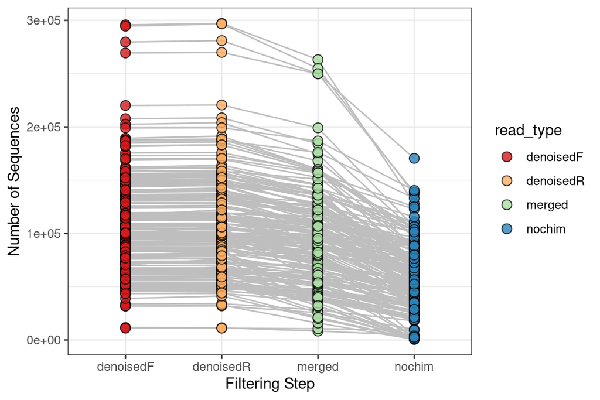

```r
# Plot it!
track_counts_df %>%
  pivot_longer(denoisedF:nochim, names_to = "read_type", values_to = "num_reads") %>%
  mutate(read_type = fct_relevel(read_type, "denoisedF", "denoisedR", "merged", "nochim")) %>%
  ggplot(aes(x = read_type, y = num_reads, fill = read_type)) +
  geom_line(aes(group = sample_names), color = "grey") +
  geom_point(shape = 21, size = 3, alpha = 0.8) +
  scale_fill_brewer(palette = "Spectral") +
  labs(x = "Filtering Step", y = "Number of Sequences") +
  theme_bw()
```

Now, let’s plot the number of sequences that have been maintained in our samples using `geom_histogram()`.

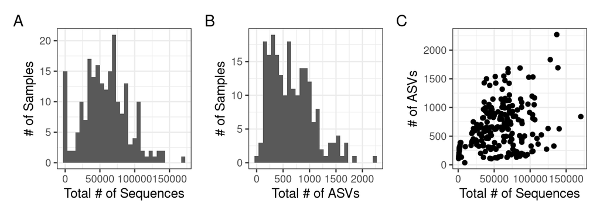

```r
plot_ReadDepth <-
  track_counts_df %>%
  ggplot(aes(x = nochim)) +
  geom_histogram() +
  labs(x = "Total # of Sequences", y = "# of Samples") +
  theme_bw()

# What is the ASV richness per sample?
plot_ASVRichness <-
  track_counts_df %>%
  ggplot(aes(x = num_ASVs)) +
  geom_histogram() +
  labs(x = "Total # of ASVs", y = "# of Samples") +
  theme_bw()

# Now, let's look at the relationship of ASVs and Sequencing depth
plot_ReadDepth_ASVRichness <-
  track_counts_df %>%
  ggplot(aes(x = nochim, y = num_ASVs)) +
  geom_point() +
  labs(x = "Total # of Sequences", y = "# of ASVs") +
  theme_bw()

# Show the plots together
plot_ReadDepth + plot_ASVRichness + plot_ReadDepth_ASVRichness +
    plot_annotation(tag_levels = 'A')
```

INTERPRETATION #5: What conclusions can you draw from each of the three individual plots above? Please note anything important that the figure might indicate regarding your project data. Are there any specific notes and considerations for later?

The figure above consists of three plots that summarize sequencing depth, ASV richness, and their relationship after DADA2 processing of 16S rRNA gene sequencing data.

**Panel A: Read Depth after DADA2:** Histogram of sequencing depth per sample (Total # of Sequences)

**Panel B: ASV Richness after DADA2:** Histogram of ASV richness (Total # of ASVs per sample)

- Most samples have ~250–1000 ASVs, following a similar unimodal distribution as sequencing depth.
- About 1 or 2 samples have very low ASV counts (~0-10). *Perhaps this corresponds to low read depth?*

**Panel C: Read Depth vs ASV Richness:** Scatter plot showing the relationship between sequencing depth and ASV richness.

- Similar to the class data, generally there might be a positive correlation, where samples with higher read depth tend to have more ASVs.

**Overall Interpretation & Considerations**

1. *Sequencing depth variation*: Most samples cluster around a common sequencing depth, but there are at least 15 samples that are likely under-sequenced.
2. *ASV richness follows read depth trends*: Samples with low sequencing depth exhibit reduced ASV richness, which may introduce bias in ecological interpretations
3. *Rarefaction or normalization may be needed*: The plot on the right indicates that richness estimates are affected by read depth. As discussed in class, rarefying or using statistical corrections will be necessary for accurate comparative analysis.

# Assign Taxonomy

```r
# Assign up to genus level
taxa_train <-
  assignTaxonomy(noChimeras_ASV_table,
                 refFasta = "/workdir/in_class_data/taxonomy/silva_nr99_v138.2_toGenus_trainset.fa.gz",
                 multithread = n_threads)

# Add the genus/species information
taxa_addSpecies <-
  addSpecies(taxa_train,
              refFasta = "/workdir/in_class_data/taxonomy/silva_v138.2_assignSpecies.fa.gz")

# Inspect the taxonomy
glimpse(taxa_addSpecies) # Note that the rownames are the ASV sequences!
```

```
##  chr [1:75334, 1:7] "Bacteria" "Bacteria" "Bacteria" "Bacteria" "Bacteria" ...
##  - attr(*, "dimnames")=List of 2
##   ..$ : chr [1:75334] "TAGGGAATCTTCCGCAATGGGCGAAAGCCTGACGGAGCGACGCCGCGTGAGCGAAGAAGGCCTTCGGGTCGTAAAGCTCTGTTGTGAGGGACGAAGGAGCGCCGTTCGAAG"| __truncated__ "TGGGGAATATTGGACAATGGGGGGAACCCTGATCCAGCCATGCCGCGTGTGTGAAGAAGGCCTTTTGGTTGTAAAGCACTTTAAGCGAGGAGGAGGCTACTCTAGTTAATA"| __truncated__ "TAGGGAATCTTCGGCA…
##   ..$ : chr [1:7] "Kingdom" "Phylum" "Class" "Order" ...
```

```r
# Let's removing the ASV sequence rownames for display only
taxa_print <- taxa_addSpecies
rownames(taxa_print) <- NULL
head(taxa_print)
```

```
##      Kingdom    Phylum           Class                 Order
## [1,] "Bacteria" "Bacillota"      "Bacilli"             "Bacillales"
## [2,] "Bacteria" "Pseudomonadota" "Gammaproteobacteria" "Pseudomonadales"
## [3,] "Bacteria" "Bacillota"      "Bacilli"             "Lactobacillales"
## [4,] "Bacteria" "Pseudomonadota" "Gammaproteobacteria" "Pseudomonadales"
## [5,] "Bacteria" "Deinococcota"   "Deinococci"          "Thermales"
## [6,] "Bacteria" "Pseudomonadota" "Gammaproteobacteria" "Pseudomonadales"
##      Family             Genus           Species
## [1,] "Bacillaceae"      "Geobacillus"   NA
## [2,] "Moraxellaceae"    "Acinetobacter" NA
## [3,] "Streptococcaceae" "Lactococcus"   NA
## [4,] "Moraxellaceae"    "Acinetobacter" NA
## [5,] "Thermaceae"       "Thermus"       NA
## [6,] "Pseudomonadaceae" "Pseudomonas"   NA
```

```r
#View(taxa_print)
```

# Export the Data

Remember from the beginning of the file under “Goals”, we wanted to export 4 different types of information:

1. ASV Count Table: `asv_table` (with and without sequence names)
2. ASV fasta file: `asvs_fasta` for building a phylogenetic tree at a later step.
3. Taxonomy Table `tax_table`
4. Sample Information: `sample_data` track the reads lots throughout DADA2 workflow.

## 1. ASV Tables

We will export the following two ASV count tables, which will be in “long” format where the **ASVs are in rows** and the **sample names are in the columns.**

1. **With ASV seqs:** ASV headers include the *entire* ASV sequence.
2. **with ASV names:** This includes re-written and shortened headers like ASV_1, ASV_2, etc, which will match the names in our fasta file below.

### Structure of ASV tables

Let’s check that the ASVs are in the rows and the sample names are in the columns. If not, we can use the transpose function `t()` in R.

```r
# What's the current format of the ASV table?
head(rownames(noChimeras_ASV_table)) # Samples!
```

```
## [1] "ERR3141386_1_filtered.fastq.gz" "ERR3141387_1_filtered.fastq.gz"
## [3] "ERR3141388_1_filtered.fastq.gz" "ERR3141389_1_filtered.fastq.gz"
## [5] "ERR3141390_1_filtered.fastq.gz" "ERR3141391_1_filtered.fastq.gz"
```

```r
head(colnames(noChimeras_ASV_table)) # ASV Sequences
```

```
## [1] "TAGGGAATCTTCCGCAATGGGCGAAAGCCTGACGGAGCGACGCCGCGTGAGCGAAGAAGG…"
## [2] "TGGGGAATATTGGACAATGGGGGGAACCCTGATCCAGCCATGCCGCGTGTGTGAAGAAGG…"
## [3] "TAGGGAATCTTCGGCAATGGACGAAAGTCTGACCGAGCAACGCCGCGTGAGTGAAGAAGG…"
## [4] "TGGGGAATATTGGACAATGGGGGGAACCCTGATCCAGCCATGCCGCGTGTGTGAAGAAGG…"
## [5] "TTAGGAATCTTCCGCAATGGGCGCAAGCCTGACGGAGCGACGCCGCTTGGAGGAAGAAGC…"
## [6] "TGGGGAATATTGGACAATGGGCGAAAGCCTGATCCAGCCATGCCGCGTGTGTGAAGAAGG…"
```

```r
# Therefore, we need to transpose the matrix
final_ASV_table_withSeqs <- t(noChimeras_ASV_table)

# Intuition check
head(rownames(final_ASV_table_withSeqs)) # ASV Sequences
```

```
## [1] "TAGGGAATCTTCCGCAATGGGCGAAAGCCTGACGGAGCGACGCCGCGTGAGCGAAGAAGG…"
## [2] "TGGGGAATATTGGACAATGGGGGGAACCCTGATCCAGCCATGCCGCGTGTGTGAAGAAGG…"
## [3] "TAGGGAATCTTCGGCAATGGACGAAAGTCTGACCGAGCAACGCCGCGTGAGTGAAGAAGG…"
## [4] "TGGGGAATATTGGACAATGGGGGGAACCCTGATCCAGCCATGCCGCGTGTGTGAAGAAGG…"
## [5] "TTAGGAATCTTCCGCAATGGGCGCAAGCCTGACGGAGCGACGCCGCTTGGAGGAAGAAGC…"
## [6] "TGGGGAATATTGGACAATGGGCGAAAGCCTGATCCAGCCATGCCGCGTGTGTGAAGAAGG…"
```

```r
head(colnames(final_ASV_table_withSeqs)) # Sample names
```

```
## [1] "ERR3141386_1_filtered.fastq.gz" "ERR3141387_1_filtered.fastq.gz"
## [3] "ERR3141388_1_filtered.fastq.gz" "ERR3141389_1_filtered.fastq.gz"
## [5] "ERR3141390_1_filtered.fastq.gz" "ERR3141391_1_filtered.fastq.gz"
```

### Names in ASV tables

#### Fix Sample Names

Notice above that the sample names are actually file names. Let’s fix this!

```r
# Remember at the top of the file we created a vector of sample names
head(sample_names)
```

```
## [1] "ERR3141386" "ERR3141387" "ERR3141388" "ERR3141389" "ERR3141390"
## [6] "ERR3141391"
```

```r
# Let's check with the actual column names
head(colnames(final_ASV_table_withSeqs)) # Sample names
```

```
## [1] "ERR3141386_1_filtered.fastq.gz" "ERR3141387_1_filtered.fastq.gz"
## [3] "ERR3141388_1_filtered.fastq.gz" "ERR3141389_1_filtered.fastq.gz"
## [5] "ERR3141390_1_filtered.fastq.gz" "ERR3141391_1_filtered.fastq.gz"
```

```r
# And then apply our sample name script to check, too
head(sapply(strsplit(colnames(final_ASV_table_withSeqs), "_"), `[`,1)) # Looks good!
```

```
## [1] "ERR3141386" "ERR3141387" "ERR3141388" "ERR3141389" "ERR3141390"
## [6] "ERR3141391"
```

```r
# Now, add a break in the script break if this isn't true!
# Let's make sure the sample names match the file names in the matrix.
stopifnot(sapply(strsplit(colnames(final_ASV_table_withSeqs), "_"), `[`,1) == sample_names)

# Now, we've done some checks to prove to ourselves there will be no silent errors,
# Let's rename!
colnames(final_ASV_table_withSeqs) <- sample_names
head(colnames(final_ASV_table_withSeqs))
```

```
## [1] "ERR3141386" "ERR3141387" "ERR3141388" "ERR3141389" "ERR3141390"
## [6] "ERR3141391"
```

#### Rename ASVs

Then, we can also fix the names of our ASVs for our second ASV table where we will replace the ASV sequence names with ASV_1, ASV_2 etc..

```r
# Give headers more manageable names
# First pull the ASV sequences from the rownames
ASV_seqs <- rownames(final_ASV_table_withSeqs)
ASV_seqs[1:5]
```

```
## [1] "TAGGGAATCTTCCGCAATGGGCGAAAGCCTGACGGAGCGACGCCGCGTGAGCGAAGAAGG…"
## [2] "TGGGGAATATTGGACAATGGGGGGAACCCTGATCCAGCCATGCCGCGTGTGTGAAGAAGG…"
## [3] "TAGGGAATCTTCGGCAATGGACGAAAGTCTGACCGAGCAACGCCGCGTGAGTGAAGAAGG…"
## [4] "TGGGGAATATTGGACAATGGGGGGAACCCTGATCCAGCCATGCCGCGTGTGTGAAGAAGG…"
## [5] "TTAGGAATCTTCCGCAATGGGCGCAAGCCTGACGGAGCGACGCCGCTTGGAGGAAGAAGC…"
```

```r
# How many ASVs?
num_ASVs <- dim(final_ASV_table_withSeqs)[1] # select the number of rows
num_ASVs
```

```
## [1] 75334
```

```r
# Make an empty vector the length of the number of ASVs,
# which is where we will place the new operational ASV names
ASV_headers <- vector(num_ASVs, mode = "character")

# Let's mae sure we have an empty vector!
ASV_headers[1:5]
```

```
## [1] "" "" "" "" ""
```

```r
length(ASV_headers) # looks good!
```

```
## [1] 75334
```

```r
# Now, let's create a vector with ASV numbers
# loop through vector and fill it in with ASV names
for (i in 1:num_ASVs) {
  # Add leading zero to ASV name so they print in correct order.
  ASV_number <- sprintf("%04d", i)
  # Now, rename each spot in the ASV header vector as we loop through the for loop
  ASV_headers[i] <- paste(">ASV", ASV_number, sep = "_")
}

# Intuition check
ASV_headers[1:5]
```

```
## [1] ">ASV_0001" ">ASV_0002" ">ASV_0003" ">ASV_0004" ">ASV_0005"
```

```r
# Create a new ASV table, which will have the ASV numbers as names
# View(noChimeras_ASV_table) # To view the table
final_ASV_table <- final_ASV_table_withSeqs
glimpse(final_ASV_table)
```

```
##  int [1:75334, 1:208] 7 1162 1705 438 0 39 59 78 56 0 ...
##  - attr(*, "dimnames")=List of 2
##   ..$ : chr [1:75334] "TAGGGAATCTTCCGCAATGGGCGAAAGCCTGACGGAGCGACGCCGCGTGAGCGAAGAAGGCCTTCGGGTCGTAAAGCTCTGTTGTGAGGGACGAAGGAGCGCCGTTCGAAG"| __truncated__ "TGGGGAATATTGGACAATGGGGGGAACCCTGATCCAGCCATGCCGCGTGTGTGAAGAAGGCCTTTTGGTTGTAAAGCACTTTAAGCGAGGAGGAGGCTACTCTAGTTAATA"| __truncated__ "TAGGGAATCTTCGGCA…
##   ..$ : chr [1:208] "ERR3141386" "ERR3141387" "ERR3141388" "ERR3141389" ...
```

```r
## Replace the ASV seqs with the ASV numbers
row.names(final_ASV_table) <- sub(">", "", ASV_headers)
final_ASV_table[1:5, 1:5]
```

```
##          ERR3141386 ERR3141387 ERR3141388 ERR3141389 ERR3141390
## ASV_0001          7          0         15          0          0
## ASV_0002       1162         94      24197       2134          0
## ASV_0003       1705        146      16118      60333        299
## ASV_0004        438        126      11126       1045          0
## ASV_0005          0          0          0          0          0
```

```r
#View(final_ASV_table) # To view the table
```

### Write the ASV Tables!

1. **With ASV seqs:** ASV headers include the *entire* ASV sequence.
2. **with ASV names:** This includes re-written and shortened headers like ASV_1, ASV_2, etc, which will match the names in our fasta file below.

```r
# 1. Write count table with ASV sequence names
write.table(final_ASV_table_withSeqs,
            file = "data/01_DADA2/ASV_table_withSeqNames.tsv",
            sep = "\t", quote = FALSE, col.names = NA)

# 2. Write count table with ASV numbered names (e.g. ASV_1, ASV_2, etc)
write.table(final_ASV_table,
            file = "data/01_DADA2/ASV_table.tsv",
            sep = "\t", quote = FALSE, col.names = NA)
```

## 2. ASV Fasta File

Now, let’s create a fasta file that has our ASV numbers with each of their corresponding ASV sequences. This file needs to be created because we will use it later to build a phylogenetic tree.

### Write the ASV Fasta File

```r
# Let's take our asv_headers
head(ASV_headers, n = 2)
```

```
## [1] ">ASV_0001" ">ASV_0002"
```

```r
# And combine it with their sequences
head(ASV_seqs, n = 2)
```

```
## [1] "TAGGGAATCTTCCGCAATGGGCGAAAGCCTGACGGAGCGACGCCGCGTGAGCGAAGAAGG…"
## [2] "TGGGGAATATTGGACAATGGGGGGAACCCTGATCCAGCCATGCCGCGTGTGTGAAGAAGG…"
```

```r
# Combine in a fasta format with the cbind() function
ASV_fasta <- c(rbind(ASV_headers, ASV_seqs))
head(ASV_fasta, n = 4)
```

```
## [1] ">ASV_0001"
## [2] "TAGGGAATCTTCCGCAATGGGCGAAAGCCTGACGGAGCGACGCCGCGTGAGCGAAGAAGG…"
## [3] ">ASV_0002"
## [4] "TGGGGAATATTGGACAATGGGGGGAACCCTGATCCAGCCATGCCGCGTGTGTGAAGAAGG…"
```

```r
# Then, let's write it to a fasta file!
# This will be our reference later on for which seq matches which ASV
write(ASV_fasta, "data/01_DADA2/ASVs.fasta")
```

## 3. Taxonomy Table

Before we actually write the taxonomy table, let’s put the ASV sequences as another column in our taxonomy table and then replace the rownames to be our numbered ASV names.

### Reformat Taxonomy

1. Move ASV sequences to column
2. Replace ASV rownames with ASV numbered names

```r
# Inspect the taxonomy table
dim(taxa_addSpecies) # ASVs are in rows and Kingdom, Phylum, etc in Columns
```

```
## [1] 75334     7
```

```r
colnames(taxa_addSpecies) # Column names are Linnean Taxonomy
```

```
## [1] "Kingdom" "Phylum"  "Class"   "Order"   "Family"  "Genus"   "Species"
```

```r
head(rownames(taxa_addSpecies), n = 2) # ASV names are rownames
```

```
## [1] "TAGGGAATCTTCCGCAATGGGCGAAAGCCTGACGGAGCGACGCCGCGTGAGCGAAGAAGG…"
## [2] "TGGGGAATATTGGACAATGGGGGGAACCCTGATCCAGCCATGCCGCGTGTGTGAAGAAGG…"
```

```r
class(taxa_addSpecies) # Character matrix
```

```
## [1] "matrix" "array"
```

```r
##### Prepare tax table
# 1. Add the ASV sequences from the rownames to a column
new_tax_table <-
  taxa_addSpecies%>%
  as.data.frame() %>%
  rownames_to_column(var = "ASVseqs")

# Intuition check
glimpse(new_tax_table)
```

```
## Rows: 75,334
## Columns: 8
## $ ASVseqs <chr> "TAGGGAATCTTCCGCAATGGGCGAAAGCCTGACGGAGCGACGCCGCGTGAGCGAAGAAGGC…
## $ Kingdom <chr> "Bacteria", "Bacteria", "Bacteria", "Bacteria", "Bacteria", "B…
## $ Phylum  <chr> "Bacillota", "Pseudomonadota", "Bacillota", "Pseudomonadota", …
## $ Class   <chr> "Bacilli", "Gammaproteobacteria", "Bacilli", "Gammaproteobacte…
## $ Order   <chr> "Bacillales", "Pseudomonadales", "Lactobacillales", "Pseudomon…
## $ Family  <chr> "Bacillaceae", "Moraxellaceae", "Streptococcaceae", "Moraxella…
## $ Genus   <chr> "Geobacillus", "Acinetobacter", "Lactococcus", "Acinetobacter"…
## $ Species <chr> NA, NA, NA, NA, NA, NA, NA, NA, NA, "raffinolactis", NA, NA, "…
```

```r
# IMPORTANT! Let's do our intuition check
# This is where we ensure we don't mix up the ASV names!
stopifnot(new_tax_table$ASVseqs == rownames(final_ASV_table_withSeqs))

# Now let's add the ASV names
rownames(new_tax_table) <- rownames(final_ASV_table)
head(new_tax_table)
```

```
##                                                                                                                                                                                                                                                                                                          …
## ASV_0001 TAGGGAATCTTCCGCAATGGGCGAAAGCCTGACGGAGCGACGCCGCGTGAGCGAAGAAGG…
## ASV_0002 TGGGGAATATTGGACAATGGGGGGAACCCTGATCCAGCCATGCCGCGTGTGTGAAGAAGG…
## ASV_0003  TAGGGAATCTTCGGCAATGGACGAAAGTCTGACCGAGCAACGCCGCGTGAGTGAAGAAGG…
## ASV_0004 TGGGGAATATTGGACAATGGGGGGAACCCTGATCCAGCCATGCCGCGTGTGTGAAGAAGG…
## ASV_0005              TTAGGAATCTTCCGCAATGGGCGCAAGCCTGACGGAGCGACGCCGCTTGGAGGAAGAAGC…
## ASV_0006  TGGGGAATATTGGACAATGGGCGAAAGCCTGATCCAGCCATGCCGCGTGTGTGAAGAAGG…
##           Kingdom         Phylum               Class           Order
## ASV_0001 Bacteria      Bacillota             Bacilli      Bacillales
## ASV_0002 Bacteria Pseudomonadota Gammaproteobacteria Pseudomonadales
## ASV_0003 Bacteria      Bacillota             Bacilli Lactobacillales
## ASV_0004 Bacteria Pseudomonadota Gammaproteobacteria Pseudomonadales
## ASV_0005 Bacteria   Deinococcota          Deinococci       Thermales
## ASV_0006 Bacteria Pseudomonadota Gammaproteobacteria Pseudomonadales
##                    Family         Genus Species
## ASV_0001      Bacillaceae   Geobacillus    <NA>
## ASV_0002    Moraxellaceae Acinetobacter    <NA>
## ASV_0003 Streptococcaceae   Lactococcus    <NA>
## ASV_0004    Moraxellaceae Acinetobacter    <NA>
## ASV_0005       Thermaceae       Thermus    <NA>
## ASV_0006 Pseudomonadaceae   Pseudomonas    <NA>
```

```r
### Final prep of tax table. Add new column with ASV names
ASV_tax_table <-
  new_tax_table %>%
  # add rownames from count table for phyloseq handoff
  mutate(ASV = rownames(final_ASV_table)) %>%
  # Reorder the columns
  dplyr::select(Kingdom, Phylum, Class, Order, Family, Genus, Species, ASV, ASVseqs)

# Assign the rownames, which is required by phyloseq
rownames(ASV_tax_table) <- ASV_tax_table$ASV

# Take a quick look
glimpse(ASV_tax_table)
```

```
## Rows: 75,334
## Columns: 9
## $ Kingdom <chr> "Bacteria", "Bacteria", "Bacteria", "Bacteria", "Bacteria", "B…
## $ Phylum  <chr> "Bacillota", "Pseudomonadota", "Bacillota", "Pseudomonadota", …
## $ Class   <chr> "Bacilli", "Gammaproteobacteria", "Bacilli", "Gammaproteobacte…
## $ Order   <chr> "Bacillales", "Pseudomonadales", "Lactobacillales", "Pseudomon…
## $ Family  <chr> "Bacillaceae", "Moraxellaceae", "Streptococcaceae", "Moraxella…
## $ Genus   <chr> "Geobacillus", "Acinetobacter", "Lactococcus", "Acinetobacter"…
## $ Species <chr> NA, NA, NA, NA, NA, NA, NA, NA, NA, "raffinolactis", NA, NA, "…
## $ ASV     <chr> "ASV_0001", "ASV_0002", "ASV_0003", "ASV_0004", "ASV_0005", "A…
## $ ASVseqs <chr> "TAGGGAATCTTCCGCAATGGGCGAAAGCCTGACGGAGCGACGCCGCGTGAGCGAAGAAGGC…
```

```r
# Intution check
stopifnot(ASV_tax_table$ASV == rownames(ASV_tax_table),
          rownames(ASV_tax_table) == rownames(ASV_tax_table))
```

### Write the Taxonomy Table

Now, let’s write out the taxonomy table

```r
# Write the table
write.table(ASV_tax_table,
            file = "data/01_DADA2/ASV_taxonomy.tsv",
            sep = "\t", quote = FALSE, col.names = NA)
```

## 4. Sample Data

Let’s save the `track_counts_df`, which can be useful for downstream analyses.

```r
# And save the track_counts_df a R object, which we will merge with metadata information in the next step of the analysis in nalysis/02_Taxonomic_Assignment.
save(track_counts_df, file = "data/01_DADA2/track_read_counts.RData")
```

# Final info for Reproducibility

## Check Render Time

```r
# Take the time now that we are at the end of the script
end_time <- Sys.time()
end_time
```

```
## [1] "2025-03-18 05:23:14 EDT"
```

```r
# Echo the elapsed time
elapsed_time <- round((end_time - start_time), 3)
elapsed_time
```

```
## Time difference of 5.308 hours
```